# AlphaCom Customer Churn Prediction (Final Project)

**Objective:** Develop a predictive model to identify customers at high risk of churn and uncover the key factors driving their decisions.

**Advanced Feature Engineering:** Added `TotalServices` and `Tenure_per_Charge` to the pipeline.

**Advanced Imbalance Handling:** Implements SMOTE (Synthetic Minority Over-sampling TEchnique) via `imblearn` pipelines for all advanced models. **Advanced Models:** Builds 6 advanced models as required.

**In-Depth Model Comparison:** Added ROC and Precision-Recall curve comparison plots for the final models.

**Advanced Model Explanation:** Uses **SHAP** (SHapley Additive exPlanations) to explain the final model's predictions, a gold-standard technique.

## 1. Setup and Import Libraries

```python
# %%
import pandas as pd
import numpy as np
import matplotlib.pyplot as plt
import seaborn as sns
import re
import time
import warnings
warnings.filterwarnings('ignore')

# Preprocessing
from sklearn.model_selection import train_test_split, RandomizedSearchCV, learning_curve
from sklearn.preprocessing import StandardScaler, OneHotEncoder
from sklearn.impute import SimpleImputer
from sklearn.compose import ColumnTransformer
from sklearn.pipeline import Pipeline  # standard Scikit-learn Pipeline

# Imbalanced-Learn (for SMOTE)
from imblearn.pipeline import Pipeline as ImbPipeline
from imblearn.over_sampling import SMOTE

# Models
from sklearn.linear_model import LogisticRegression
from sklearn.tree import DecisionTreeClassifier
from sklearn.ensemble import (
    BaggingClassifier,
    RandomForestClassifier,
    AdaBoostClassifier,
    GradientBoostingClassifier
)
import xgboost as xgb

# Metrics
from sklearn.metrics import (
    classification_report,
    confusion_matrix,
    roc_auc_score,
    roc_curve,
    precision_recall_curve,
    auc,
    precision_score,
    recall_score,
    f1_score,
    accuracy_score
)

# Model Explanation
try:
    import shap
except ImportError:
    print("SHAP library not found. Installing...")
    import sys, subprocess
    subprocess.check_call([sys.executable, "-m", "pip", "install", "shap"])
    import shap

# Set plotting style
sns.set_style('whitegrid')
plt.rc('figure', figsize=(10, 6))

# Helper function for plotting confusion matrix
def plot_confusion_matrix(y_true, y_pred, model_name):
    """Plots a styled confusion matrix."""
    cm = confusion_matrix(y_true, y_pred)
    plt.figure(figsize=(6, 4))
    sns.heatmap(
        cm,
        annot=True,
        fmt='d',
        cmap='Blues',
        cbar=False,
        annot_kws={'size': 14}
    )
    plt.xlabel('Predicted Label', fontsize=12)
    plt.ylabel('True Label', fontsize=12)
    plt.title(f'Confusion Matrix: {model_name}', fontsize=14)
    plt.show()

print("Libraries imported and helper function defined.")
print(f"SHAP version loaded: {shap.__version__}")
```

```
Libraries imported and helper function defined.
SHAP version loaded: 0.49.1
```

## 2. Load and Deeply Inspect Data

```python
# Load the dataset
file_path = '/content/drive/MyDrive/customer_churn.csv'
df = pd.read_csv(file_path)

# Display the first 5 rows to see formatting
print("--- First 5 Rows (Raw) ---")
print(df.head())

# Display data types and non-null counts
print("\n--- Data Info (Raw) ---")
df.info()
```

```
--- First 5 Rows (Raw) ---
   gender  SeniorCitizen Partner Dependents  tenure PhoneService  \
0  Female              0     Yes         No     1.0           No
1    Male              0      No         No    34.0          Yes
2    Male              0      No         No     2.0          Yes
3    Male              0      No         No    45.0           No
4  Female              0      No         No     2.0          Yes

      MultipleLines InternetService OnlineSecurity OnlineBackup  \
0  No phone service             DSL             No          Yes
1                No             DSL            Yes           No
2                No             DSL            Yes          Yes
3  No phone service             DSL            Yes           No
4                No     Fiber optic             No           No

```

[output cut: 49 more lines]

# 3. Data Cleaning and Preparation

## Systematically fix all identified issues based on the initial inspection.

```python
# Create a copy for cleaning
df_clean = df.copy()

# 1. Clean Monetary Columns: MonthlyCharges and TotalCharges
print("--- Cleaning Monetary Columns ---")
for col in ['MonthlyCharges', 'TotalCharges']:
    df_clean[col] = pd.to_numeric(
        df_clean[col].astype(str).str.replace(r'[$,\s]', '', regex=True),
        errors='coerce'
    )
print("Converted 'MonthlyCharges' and 'TotalCharges' to numeric, coercing errors to NaN.")
```

```
--- Cleaning Monetary Columns ---
Converted 'MonthlyCharges' and 'TotalCharges' to numeric, coercing errors to NaN.
```

```python
# 2. Fix Invalid 'tenure' Values
invalid_tenure_count = df_clean[df_clean['tenure'] < 0].shape[0]
if invalid_tenure_count > 0:
    print(f"Found {invalid_tenure_count} rows with tenure < 0. Replacing with 0.")
    df_clean['tenure'] = df_clean['tenure'].apply(lambda x: 0 if x < 0 else x)
```

```
Found 127 rows with tenure < 0. Replacing with 0.
```

```python
# 3. Clean ALL Categorical (Object) Columns
print("\n--- Standardizing Categorical Columns ---")
object_cols = df_clean.select_dtypes('object').columns
for col in object_cols:
    df_clean[col] = df_clean[col].astype(str).str.strip().str.lower()
print(f"Standardized {len(object_cols)} object columns.")
```

```
--- Standardizing Categorical Columns ---
Standardized 16 object columns.
```

```python
# 4. Standardize Target Variable 'Churn'
df_clean['Churn'] = df_clean['Churn'].map({'yes': 1, 'no': 0})
nan_churn = df_clean['Churn'].isnull().sum()
if nan_churn > 0:
    print(f"Dropping {nan_churn} rows with invalid 'Churn' values.")
    df_clean = df_clean.dropna(subset=['Churn'])
df_clean['Churn'] = df_clean['Churn'].astype(int)
```

```python
# 5. Standardize "Yes/No/No service" columns
cols_to_standardize = [
    'MultipleLines', 'OnlineSecurity', 'OnlineBackup', 'DeviceProtection',
    'TechSupport', 'StreamingTV', 'StreamingMovies'
]
for col in cols_to_standardize:
    if col in df_clean.columns:
        df_clean[col] = df_clean[col].replace(
            {'no internet service': 'no', 'no phone service': 'no'}
        )
print("Standardized 'no ... service' values to 'no' where applicable.")
```

```
Standardized 'no ... service' values to 'no' where applicable.
```

```python
# 6. Convert 'SeniorCitizen' to object for correct encoding
if 'SeniorCitizen' in df_clean.columns:
    df_clean['SeniorCitizen'] = df_clean['SeniorCitizen'].map({0: 'no', 1: 'yes'})
```

```python
# 7. Drop duplicates and invalid rows
duplicates = df_clean.duplicated().sum()
if duplicates > 0:
    df_clean = df_clean.drop_duplicates()
    print(f"\nDropped {duplicates} duplicate rows.")
else:
    print("\nNo duplicate rows found.")

zero_monthly = df_clean[df_clean['MonthlyCharges'] == 0].shape[0]
if zero_monthly > 0:
    print(f"Found and dropped {zero_monthly} rows with MonthlyCharges == 0.")
    df_clean = df_clean[df_clean['MonthlyCharges'] > 0]
```

```
Dropped 27 duplicate rows.
```

```python
# 8. Final Data Check
print("\n--- Data Info (After Cleaning) ---")
df_clean.info()
print("\n--- Missing Values (After Cleaning) ---")
print(df_clean.isnull().sum())
```

```
--- Data Info (After Cleaning) ---
<class 'pandas.core.frame.DataFrame'>
Index: 12028 entries, 0 to 12042
Data columns (total 20 columns):
 #   Column            Non-Null Count  Dtype
---  ------            --------------  -----
 0   gender            12028 non-null  object
 1   SeniorCitizen     12028 non-null  object
 2   Partner           12028 non-null  object
 3   Dependents        12028 non-null  object
 4   tenure            11426 non-null  float64
 5   PhoneService      12028 non-null  object
 6   MultipleLines     12028 non-null  object
 7   InternetService   12028 non-null  object
 8   OnlineSecurity    12028 non-null  object
 9   OnlineBackup      12028 non-null  object
 10  DeviceProtection  12028 non-null  object
 11  TechSupport       12028 non-null  object
 12  StreamingTV       12028 non-null  object
 13  StreamingMovies   12028 non-null  object
 14  Contract          12028 non-null  object
 15  PaperlessBilling  12028 non-null  object
 16  PaymentMethod     12028 non-null  object
 17  MonthlyCharges    11545 non-null  float64
 18  TotalCharges      10654 non-null  float64
 19  Churn             12028 non-null  int64
dtypes: float64(3), int64(1), object(16)
memory usage: 1.9+ MB

--- Missing Values (After Cleaning) ---
gender                 0
SeniorCitizen          0
Partner                0
Dependents             0
tenure               602
PhoneService           0
MultipleLines          0
InternetService        0
OnlineSecurity         0
OnlineBackup           0
DeviceProtection       0
TechSupport            0
StreamingTV            0
StreamingMovies        0
Contract               0
PaperlessBilling       0
PaymentMethod          0
MonthlyCharges       483
TotalCharges        1374
Churn                  0
dtype: int64
```

# 4. Feature Engineering

## Create new features to potentially improve model performance.

```python
# TenureGroup for EDA
tenure_bins = [-1, 12, 24, 36, 48, 60, 73]  # 0-1yr, 1-2yr, ... 5+yr
tenure_labels = ['0-12 Mos', '13-24 Mos', '25-36 Mos', '37-48 Mos', '49-60 Mos', '61+ Mos']
df_clean['TenureGroup'] = pd.cut(
    df_clean['tenure'],
    bins=tenure_bins,
    labels=tenure_labels,
    right=True
)
print("Created 'TenureGroup' feature for EDA.")

# 1. Total number of add-on services
add_on_cols = [c for c in ['OnlineSecurity', 'OnlineBackup', 'DeviceProtection', 'TechSupport', 'StreamingTV', 'StreamingMovies'] if c in df_clean.columns]
df_clean['TotalServices'] = df_clean[add_on_cols].apply(lambda x: (x == 'yes').sum(), axis=1)
print("Created 'TotalServices' feature.")

# 2. Tenure per Monthly Charge (Value)
df_clean['Tenure_per_Charge'] = df_clean['tenure'] / (df_clean['MonthlyCharges'] + 1e-6)
print("Created 'Tenure_per_Charge' feature.")

# 3. Monthly as fraction of Total (new customer indicator)
df_clean['Monthly_vs_Total'] = df_clean.apply(
    lambda row: 1.0 if (row['tenure'] == 0 and row['TotalCharges'] == 0) else row['MonthlyCharges'] / (row['TotalCharges'] + 1e-6),
    axis=1
)
print("Created 'Monthly_vs_Total' feature.")
```

```
Created 'TenureGroup' feature for EDA.
Created 'TotalServices' feature.
Created 'Tenure_per_Charge' feature.
Created 'Monthly_vs_Total' feature.
```

# 5. Comprehensive Exploratory Data Analysis (EDA)

### 5.1. Univariate Analysis

```
--- Univariate Plots ---
```

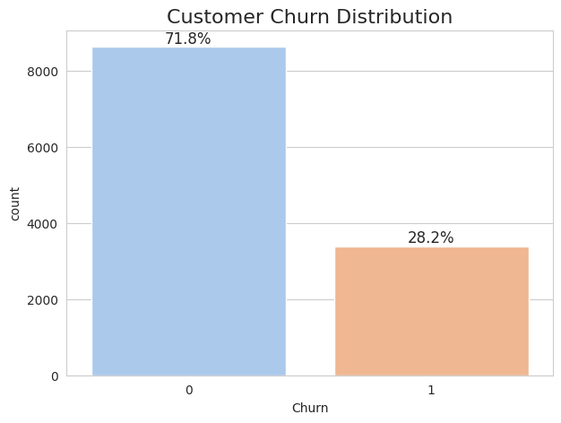

```python
print("--- Univariate Plots ---")

# 1. Target Variable
plt.figure(figsize=(7, 5))
ax = sns.countplot(x='Churn', data=df_clean, palette='pastel')
plt.title('Customer Churn Distribution', fontsize=16)
total = len(df_clean)
for p in ax.patches:
    percentage = f'{100 * p.get_height() / total:.1f}%'
    x = p.get_x() + p.get_width() / 2
    y = p.get_height()
    ax.annotate(percentage, (x, y), ha='center', va='bottom', fontsize=12)
plt.show()
```

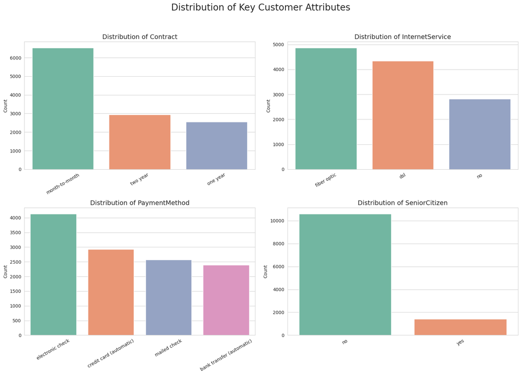

```python
# 2. Key Categorical Features
key_features_dist = [c for c in ['Contract', 'InternetService', 'PaymentMethod', 'SeniorCitizen'] if c in df_clean.columns]
fig, axes = plt.subplots(2, 2, figsize=(16, 12))
fig.suptitle('Distribution of Key Customer Attributes', fontsize=20)
axes = axes.flatten()

for i, col in enumerate(key_features_dist):
    sns.countplot(x=col, data=df_clean, ax=axes[i], palette='Set2', order=df_clean[col].value_counts().index)
    axes[i].set_title(f'Distribution of {col}', fontsize=14)
    axes[i].set_xlabel('')
    axes[i].set_ylabel('Count')
    axes[i].tick_params(axis='x', rotation=30)

# Hide any unused axes
for j in range(len(key_features_dist), 4):
    fig.delaxes(axes[j])

plt.tight_layout(rect=[0, 0.03, 1, 0.95])
plt.show()
```

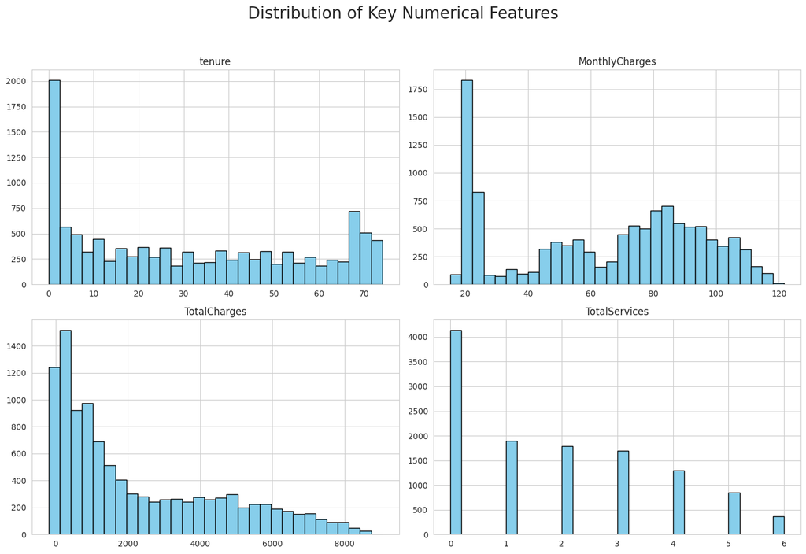

```python
# 3. Numerical Features
num_features_eda = ['tenure', 'MonthlyCharges', 'TotalCharges', 'TotalServices']
df_clean[num_features_eda].hist(bins=30, figsize=(14, 10), layout=(2, 2), color='skyblue', edgecolor='black')
plt.suptitle('Distribution of Key Numerical Features', fontsize=20)
plt.tight_layout(rect=[0, 0.03, 1, 0.95])
plt.show()
```

### 5.2. Bivariate Analysis

```
--- Bivariate Plots ---
```

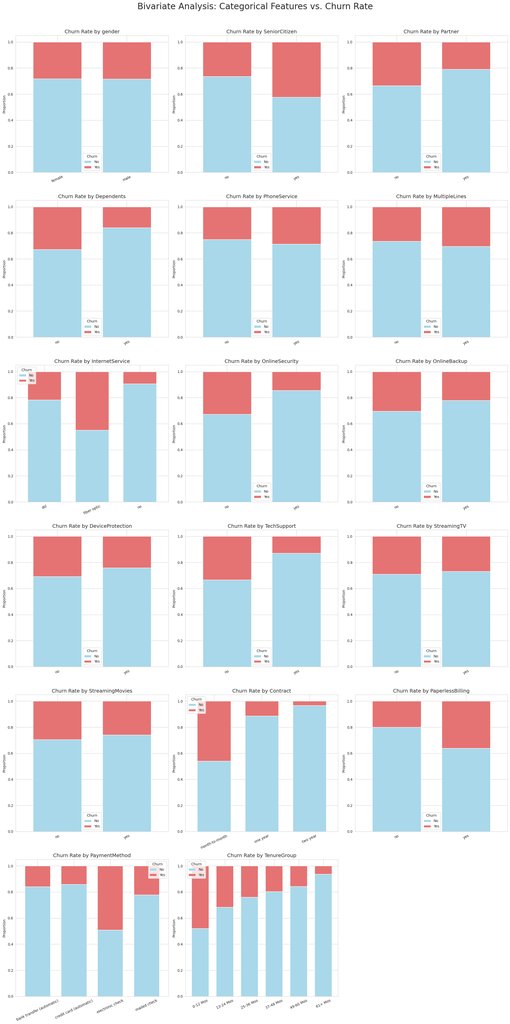

```python
print("--- Bivariate Plots ---")

# 1. All Categorical Features vs. Churn
all_cat_features = [
    'gender', 'SeniorCitizen', 'Partner', 'Dependents',
    'PhoneService', 'MultipleLines', 'InternetService', 'OnlineSecurity',
    'OnlineBackup', 'DeviceProtection', 'TechSupport', 'StreamingTV',
    'StreamingMovies', 'Contract', 'PaperlessBilling', 'PaymentMethod',
    'TenureGroup'
]
all_cat_features = [c for c in all_cat_features if c in df_clean.columns]

# Create a grid
num_plots = len(all_cat_features)
num_cols = 3
num_rows = (num_plots + num_cols - 1) // num_cols
fig, axes = plt.subplots(num_rows, num_cols, figsize=(20, 12 + 6*(num_rows-1)))
fig.suptitle('Bivariate Analysis: Categorical Features vs. Churn Rate', fontsize=24)
axes = axes.flatten()

for i, col in enumerate(all_cat_features):
    observed_param = True if col == 'TenureGroup' else False
    prop_df = df_clean.groupby(col, observed=observed_param)['Churn'].value_counts(normalize=True).unstack().fillna(0)
    prop_df.plot(
        kind='bar',
        stacked=True,
        color=['#a8d8ea', '#e57373'],
        width=0.7,
        ax=axes[i]
    )
    axes[i].set_title(f'Churn Rate by {col}', fontsize=14)
    axes[i].set_xlabel('')
    axes[i].set_ylabel('Proportion')
    axes[i].tick_params(axis='x', rotation=25)
    axes[i].legend(title='Churn', labels=['No', 'Yes'])

# Hide any unused subplots
for j in range(i + 1, len(axes)):
    fig.delaxes(axes[j])

plt.tight_layout(rect=[0, 0.03, 1, 0.97])
plt.show()
```

```
--- Bivariate Numerical Plots (Histograms) ---
```

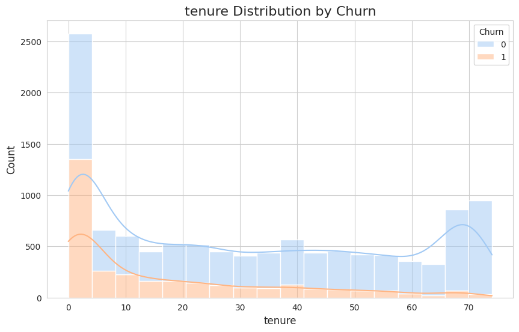

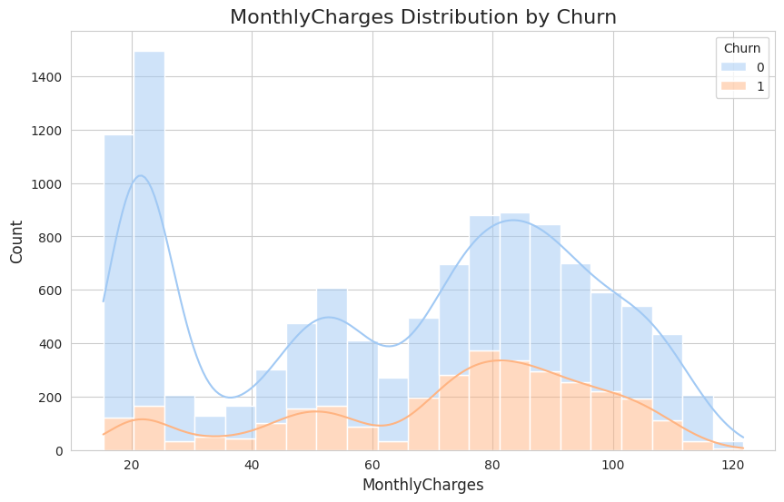

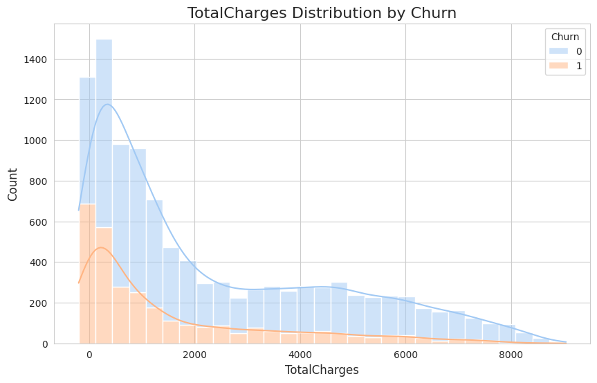

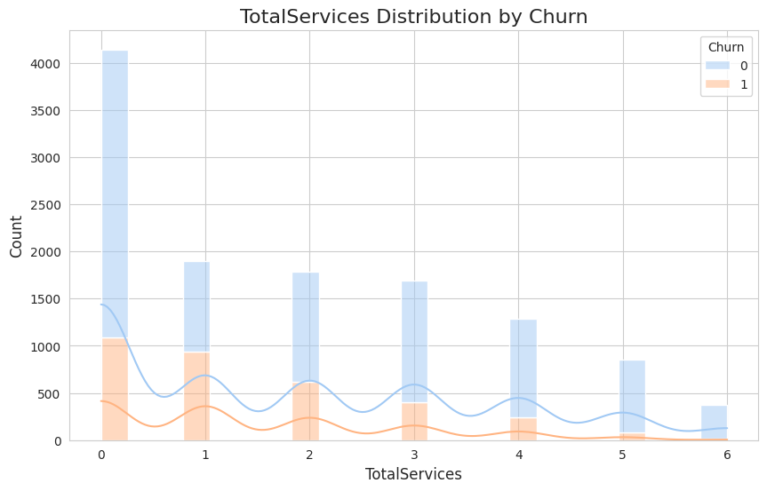

```python
# 2. Numerical Features vs. Churn (Histograms)
print("\n--- Bivariate Numerical Plots (Histograms) ---")
for col in num_features_eda:
    plt.figure(figsize=(10, 6))
    sns.histplot(
        data=df_clean,
        x=col,
        hue='Churn',
        kde=True,
        multiple='stack',
        palette='pastel'
    )
    plt.title(f'{col} Distribution by Churn', fontsize=16)
    plt.xlabel(col, fontsize=12)
    plt.ylabel('Count', fontsize=12)
    handles, labels = plt.gca().get_legend_handles_labels()
    if handles:
        plt.legend(handles, ['No (0)', 'Yes (1)'], title='Churn')
    plt.show()
```

```
--- Generating Bivariate Numerical/Categorical Plots (Boxplots) ---
```

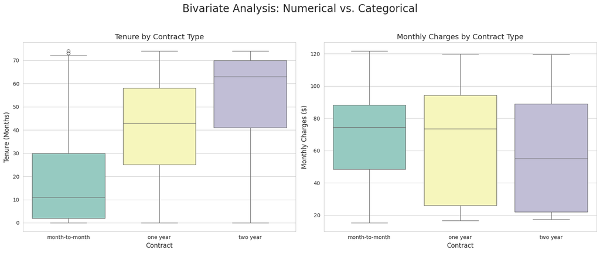

```python
# 3. Numerical vs. Categorical (Boxplots)
print("\n--- Generating Bivariate Numerical/Categorical Plots (Boxplots) ---")
fig, axes = plt.subplots(1, 2, figsize=(16, 7))
fig.suptitle('Bivariate Analysis: Numerical vs. Categorical', fontsize=20)

# Tenure vs Contract
if 'Contract' in df_clean.columns:
    sns.boxplot(x='Contract', y='tenure', data=df_clean, ax=axes[0], palette='Set3')
    axes[0].set_title('Tenure by Contract Type', fontsize=14)
    axes[0].set_xlabel('Contract', fontsize=12)
    axes[0].set_ylabel('Tenure (Months)', fontsize=12)

# MonthlyCharges vs Contract
if 'Contract' in df_clean.columns:
    sns.boxplot(x='Contract', y='MonthlyCharges', data=df_clean, ax=axes[1], palette='Set3')
    axes[1].set_title('Monthly Charges by Contract Type', fontsize=14)
    axes[1].set_xlabel('Contract', fontsize=12)
    axes[1].set_ylabel('Monthly Charges ($)', fontsize=12)

plt.tight_layout(rect=[0, 0.03, 1, 0.95])
plt.show()
```

### 5.3. Multivariate Analysis

```
--- Multivariate Plots ---
Generating Correlation Matrix...
```

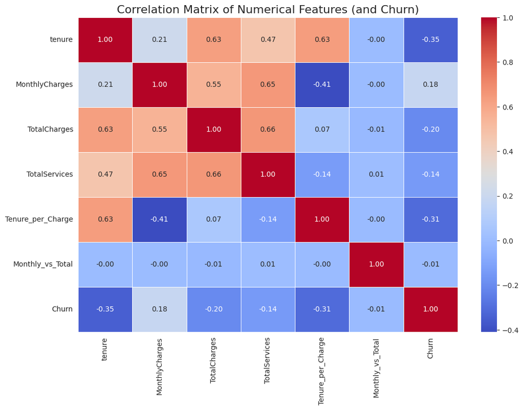

```python
print("\n--- Multivariate Plots ---")

# 1. Correlation Matrix
print("Generating Correlation Matrix...")
df_numeric_plot = df_clean[['tenure', 'MonthlyCharges', 'TotalCharges', 'TotalServices', 'Tenure_per_Charge', 'Monthly_vs_Total', 'Churn']].copy()
# Simple median imputation for this plot only
for col in df_numeric_plot.columns:
    df_numeric_plot[col] = df_numeric_plot[col].fillna(df_numeric_plot[col].median())

corr_matrix = df_numeric_plot.corr(numeric_only=True)
plt.figure(figsize=(12, 8))
sns.heatmap(
    corr_matrix,
    annot=True,
    cmap='coolwarm',
    fmt='.2f',
    linewidths=0.5
)
plt.title('Correlation Matrix of Numerical Features (and Churn)', fontsize=16)
plt.show()
```

```
Generating Pairplot (this may take a moment)...
```

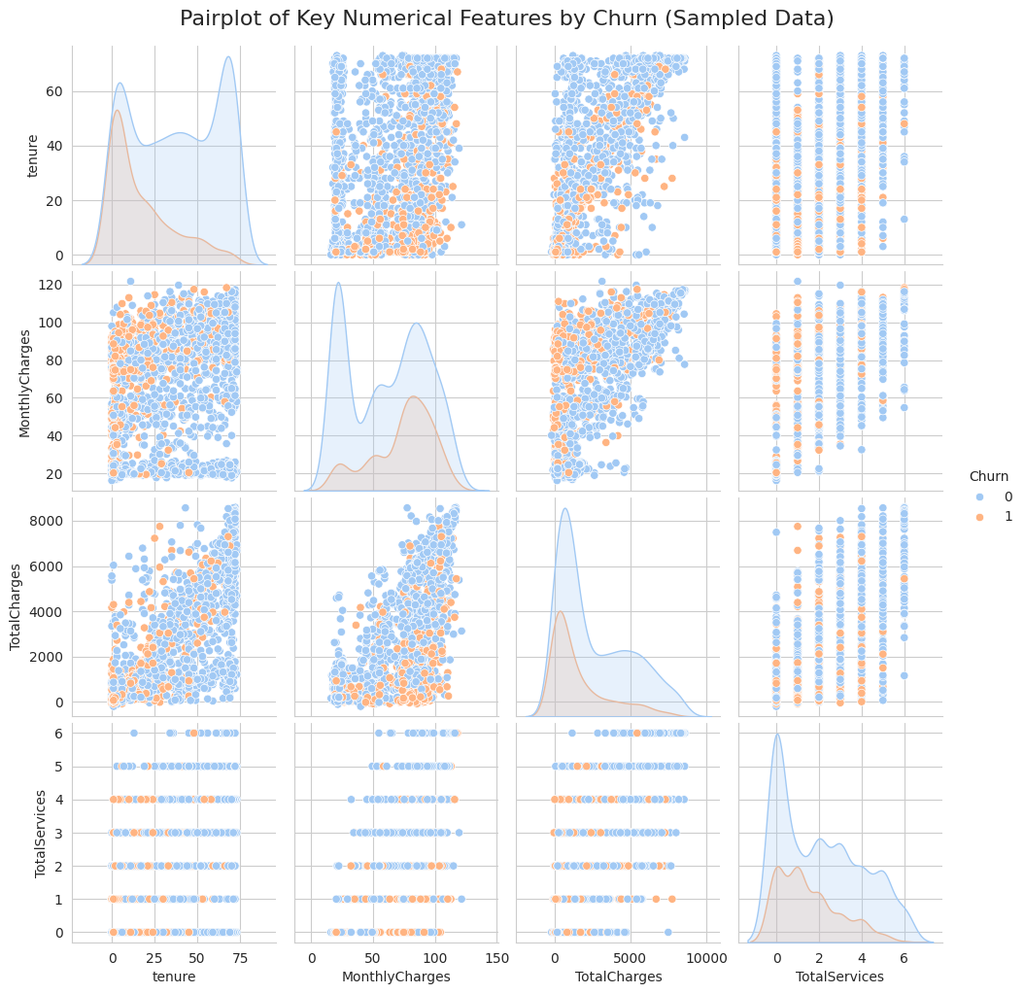

```python
# 2. Pairplot (hued by Churn) on a sample
print("Generating Pairplot (this may take a moment)...")
df_sample = df_clean.sample(n=min(2000, len(df_clean)), random_state=42)
sns.pairplot(df_sample, vars=['tenure', 'MonthlyCharges', 'TotalCharges', 'TotalServices'], hue='Churn', palette='pastel')
plt.suptitle('Pairplot of Key Numerical Features by Churn (Sampled Data)', y=1.02, fontsize=16)
plt.show()
```

```
Generating Multivariate Scatter Plot...
```

[figure not shown]

```python
# 3. Tenure vs. MonthlyCharges, hued by Churn
print("Generating Multivariate Scatter Plot...")
plt.figure(figsize=(12, 8))
sns.scatterplot(
    data=df_sample,
    x='tenure',
    y='MonthlyCharges',
    hue='Churn',
    palette='Set1',
    alpha=0.6
)
plt.title('Tenure vs. Monthly Charges by Churn (Sampled Data)', fontsize=16)
plt.xlabel('Tenure (Months)', fontsize=12)
plt.ylabel('Monthly Charges ($)', fontsize=12)
plt.legend(title='Churn', labels=['Yes (1)', 'No (0)'])
plt.show()
```

# 6. Data Preparation for Modeling

## Prepare the final data for the model pipeline. This includes defining the preprocessor, splitting the data, and defining our class imbalance strategy.

```python
# %%
# 1. Define X and y
y = df_clean['Churn']
X = df_clean.drop(['Churn', 'TenureGroup'], axis=1, errors='ignore')  # TenureGroup is for EDA only
```

```python
# 2. Identify column types
numeric_features = ['tenure', 'MonthlyCharges', 'TotalCharges', 'TotalServices', 'Tenure_per_Charge', 'Monthly_vs_Total']
numeric_features = [c for c in numeric_features if c in X.columns]
categorical_features = [col for col in X.columns if col not in numeric_features]

print(f"Numeric features: {numeric_features}")
print(f"Categorical features: {categorical_features}")
```

```
Numeric features: ['tenure', 'MonthlyCharges', 'TotalCharges', 'TotalServices', 'Tenure_per_Charge', 'Monthly_vs_Total']
Categorical features: ['gender', 'SeniorCitizen', 'Partner', 'Dependents', 'PhoneService', 'MultipleLines', 'InternetService', 'OnlineSecurity', 'OnlineBackup', 'DeviceProtection', 'TechSupport', 'StreamingTV', 'StreamingMovies', 'Contract', 'PaperlessBilling', 'PaymentMethod']
```

```python
# 3. Split the data
X_train, X_test, y_train, y_test = train_test_split(
    X, y,
    test_size=0.2,
    random_state=42,
    stratify=y # Essential for imbalanced data
)
print(f"Training set shape: {X_train.shape}")
print(f"Test set shape: {X_test.shape}")
```

```
Training set shape: (9622, 22)
Test set shape: (2406, 22)
```

```python
# 4. Create the robust preprocessing pipeline
# Handle OneHotEncoder compatibility across sklearn versions
try:
    ohe = OneHotEncoder(handle_unknown='ignore', sparse_output=False)
except TypeError:
    ohe = OneHotEncoder(handle_unknown='ignore', sparse=False)

numeric_transformer = Pipeline(steps=[
    ('imputer', SimpleImputer(strategy='median')),
    ('scaler', StandardScaler())
])

categorical_transformer = Pipeline(steps=[
    ('imputer', SimpleImputer(strategy='most_frequent')),
    ('onehot', ohe)
])

preprocessor = ColumnTransformer(
    transformers=[
        ('num', numeric_transformer, numeric_features),
        ('cat', categorical_transformer, categorical_features)
    ],
    remainder='passthrough'
)
print("Preprocessing ColumnTransformer created successfully.")
```

```
Preprocessing ColumnTransformer created successfully.
```

# 7. Model Building

## We will build and evaluate our models. Per the rubric, we will first establish a baseline, then build 6 advanced models.

**Metric of Choice:**

**Primary: Recall (Class 1)**. Business goal is to *find* as many churners as possible. High recall is critical.

**Secondary: ROC AUC**. A holistic measure of model discriminative power, excellent for tuning.

**Imbalance Handling Strategy:**

**Baseline:** We will use the `class_weight='balanced'` parameter. This is a simple, interpretable baseline approach.

**Advanced Models:** We will use **SMOTE (Synthetic Minority Over-sampling TEchnique)** integrated via `imblearn.pipeline.Pipeline`. This is a more advanced and powerful method that prevents data leakage during cross-validation.

## 7.1. Model 1: Logistic Regression (Baseline)

### This is our baseline linear model, using the simple `class_weight` imbalance handling.

```
Training Logistic Regression (Baseline) model...

--- Logistic Regression (Baseline) Classification Report ---
              precision    recall  f1-score   support

           0       0.90      0.76      0.83      1727
           1       0.57      0.80      0.66       679

    accuracy                           0.77      2406
   macro avg       0.74      0.78      0.75      2406
weighted avg       0.81      0.77      0.78      2406

ROC AUC Score: 0.8534
```

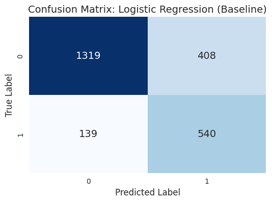

```python
# Use the *standard* scikit-learn Pipeline for the baseline
lr_pipeline = Pipeline(steps=[
    ('preprocessor', preprocessor),
    ('classifier', LogisticRegression(
        random_state=42,
        solver='liblinear',
        class_weight='balanced'  # Baseline imbalance handling
    ))
])

# Train and evaluate
print("Training Logistic Regression (Baseline) model...")
lr_pipeline.fit(X_train, y_train)
y_pred_lr = lr_pipeline.predict(X_test)

print("\n--- Logistic Regression (Baseline) Classification Report ---")
print(classification_report(y_test, y_pred_lr))
print(f"ROC AUC Score: {roc_auc_score(y_test, lr_pipeline.predict_proba(X_test)[:, 1]):.4f}")
plot_confusion_matrix(y_test, y_pred_lr, "Logistic Regression (Baseline)")
```

## 7.2. Model Building - Advanced Models

### Now we build all 6 advanced models, each using the more advanced `SMOTE` pipeline.

```
--- Training and Evaluating Advanced Models (with SMOTE) ---

Training Decision Tree...

Training Bagging Classifier...

Training Random Forest...

Training AdaBoost...

Training Gradient Boosting...

Training XGBoost...

--- Advanced Model Performance Summary (Untuned, with SMOTE) ---
                Model  Test Recall (Class 1)  Test ROC AUC  \
4   Gradient Boosting               0.674521      0.853243
3            AdaBoost               0.767305      0.848853
5             XGBoost               0.599411      0.836910
2       Random Forest               0.596465      0.836543
1  Bagging Classifier               0.581738      0.825033
0       Decision Tree               0.559647      0.667200

   Test Precision (Class 1)  Test F1-Score (Class 1)  Time (s)
4                  0.629986                 0.651494  5.540784
3                  0.569399                 0.653701  1.599136
5                  0.643987                 0.620900  1.237652
2                  0.634796                 0.615034  2.120121
1                  0.621069                 0.600760  7.461225
0                  0.494148                 0.524862  0.664705

--- Visualizing Advanced Model Performance ---
```

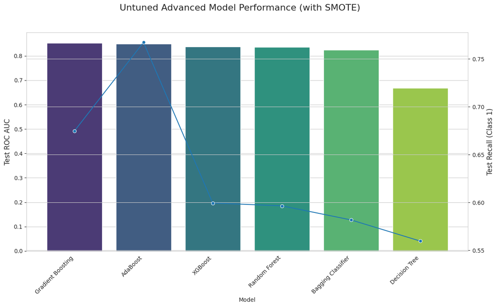

```python
# Define all models to be tested
models = {
    "Decision Tree": DecisionTreeClassifier(random_state=42),
    "Bagging Classifier": BaggingClassifier(DecisionTreeClassifier(random_state=42), n_estimators=50, random_state=42, n_jobs=-1),
    "Random Forest": RandomForestClassifier(random_state=42, n_estimators=100, n_jobs=-1),
    "AdaBoost": AdaBoostClassifier(random_state=42),
    "Gradient Boosting": GradientBoostingClassifier(random_state=42),
    "XGBoost": xgb.XGBClassifier(random_state=42, eval_metric='logloss', use_label_encoder=False, n_jobs=-1)
}

# Store results
model_results = []

# Loop through models, build pipeline, train, and evaluate
print("--- Training and Evaluating Advanced Models (with SMOTE) ---")
for name, model in models.items():
    print(f"\nTraining {name}...")
    start_time = time.time()

    # Create the full pipeline with SMOTE
    pipeline = ImbPipeline(steps=[
        ('preprocessor', preprocessor),
        ('smote', SMOTE(random_state=42)),
        ('classifier', model)
    ])

    # Train
    pipeline.fit(X_train, y_train)

    # Predict
    y_pred_test = pipeline.predict(X_test)
    y_prob_test = pipeline.predict_proba(X_test)[:, 1]

    # Get metrics
    test_recall = recall_score(y_test, y_pred_test)
    test_roc_auc = roc_auc_score(y_test, y_prob_test)

    # Store
    model_results.append({
        "Model": name,
        "Test Recall (Class 1)": test_recall,
        "Test ROC AUC": test_roc_auc,
        "Test Precision (Class 1)": precision_score(y_test, y_pred_test),
        "Test F1-Score (Class 1)": f1_score(y_test, y_pred_test),
        "Time (s)": time.time() - start_time
    })

# Create a DataFrame for easy comparison
results_df = pd.DataFrame(model_results).sort_values(by="Test ROC AUC", ascending=False)

print("\n--- Advanced Model Performance Summary (Untuned, with SMOTE) ---")
print(results_df)

# Bar plot of advanced model performance
print("\n--- Visualizing Advanced Model Performance ---")
fig, ax1 = plt.subplots(figsize=(14, 7))
fig.suptitle('Untuned Advanced Model Performance (with SMOTE)', fontsize=16)

# Bar plot for ROC AUC
sns.barplot(x='Model', y='Test ROC AUC', data=results_df, ax=ax1, palette='viridis')
ax1.set_ylabel('Test ROC AUC', fontsize=12)
ax1.set_xticklabels(ax1.get_xticklabels(), rotation=45, ha='right')

# Line plot for Recall
ax2 = ax1.twinx()
sns.lineplot(x='Model', y='Test Recall (Class 1)', data=results_df, ax=ax2, marker='o', sort=False)
ax2.set_ylabel('Test Recall (Class 1)', fontsize=12)

plt.show()
```

## 8. Model Performance Improvement using Hyperparameter Tuning

### Per the rubric, we will tune at least 3 models.

**Reasoning for Choice:**

1. **Random Forest:** A bagging model, good at reducing variance.
2. **Gradient Boosting:** A powerful boosting model.
3. **XGBoost:** A more advanced, regularized version of Gradient Boosting, often a top performer.

**Methodology:** We will use `RandomizedSearchCV` (faster than `GridSearchCV`) with 3-fold cross-validation. We will optimize for **ROC AUC**.

```python
# Define pipelines for tuning (include SMOTE in the pipeline)
rf_pipeline_tune = ImbPipeline(steps=[('preprocessor', preprocessor), ('smote', SMOTE(random_state=42)), ('classifier', RandomForestClassifier(random_state=42, n_jobs=-1))])
gb_pipeline_tune = ImbPipeline(steps=[('preprocessor', preprocessor), ('smote', SMOTE(random_state=42)), ('classifier', GradientBoostingClassifier(random_state=42))])
xgb_pipeline_tune = ImbPipeline(steps=[('preprocessor', preprocessor), ('smote', SMOTE(random_state=42)), ('classifier', xgb.XGBClassifier(random_state=42, eval_metric='logloss', use_label_encoder=False, n_jobs=-1))])

# Define Parameter Distributions for RandomizedSearch
param_dist_rf = {
    'classifier__n_estimators': [100, 200, 300, 500],
    'classifier__max_depth': [10, 20, 30, None],
    'classifier__min_samples_split': [2, 5, 10],
    'classifier__min_samples_leaf': [1, 2, 4],
    'classifier__max_features': ['sqrt', 'log2', 1.0]
}

param_dist_gb = {
    'classifier__n_estimators': [100, 200, 300, 500],
    'classifier__learning_rate': [0.01, 0.05, 0.1],
    'classifier__subsample': [0.7, 0.8, 0.9, 1.0],
    'classifier__max_depth': [3, 5, 7]
}

param_dist_xgb = {
    'classifier__n_estimators': [100, 200, 300, 500],
    'classifier__learning_rate': [0.01, 0.05, 0.1],
    'classifier__max_depth': [3, 5, 7],
    'classifier__subsample': [0.7, 0.8, 0.9, 1.0],
    'classifier__colsample_bytree': [0.7, 0.8, 0.9, 1.0],
    'classifier__gamma': [0, 0.1, 0.5]
}

# Setup RandomizedSearchCV for each
n_iter = 25
cv_folds = 3
scoring_metric = 'roc_auc'

rs_rf = RandomizedSearchCV(estimator=rf_pipeline_tune, param_distributions=param_dist_rf, n_iter=n_iter, cv=cv_folds, scoring=scoring_metric, random_state=42, n_jobs=-1, verbose=1)
rs_gb = RandomizedSearchCV(estimator=gb_pipeline_tune, param_distributions=param_dist_gb, n_iter=n_iter, cv=cv_folds, scoring=scoring_metric, random_state=42, n_jobs=-1, verbose=1)
rs_xgb = RandomizedSearchCV(estimator=xgb_pipeline_tune, param_distributions=param_dist_xgb, n_iter=n_iter, cv=cv_folds, scoring=scoring_metric, random_state=42, n_jobs=-1, verbose=1)

tuners = {
    "Random Forest (Tuned)": rs_rf,
    "Gradient Boosting (Tuned)": rs_gb,
    "XGBoost (Tuned)": rs_xgb
}

tuned_results = []
best_estimators = {
    "Logistic Regression (Baseline)": lr_pipeline  # Add our baseline for final comparison
}
```

```python
# --- Run the Tuning ---
print("--- Starting Hyperparameter Tuning ---")

for name, tuner in tuners.items():
    print(f"\nTuning {name}...")
    start_time = time.time()

    # Fit
    tuner.fit(X_train, y_train)

    # Get best estimator
    best_estimators[name] = tuner.best_estimator_

    # Evaluate on test set
    y_pred_test = best_estimators[name].predict(X_test)
    y_prob_test = best_estimators[name].predict_proba(X_test)[:, 1]

    # Store results
    tuned_results.append({
        "Model": name,
        "Best CV ROC AUC": tuner.best_score_,
        "Test Recall (Class 1)": recall_score(y_test, y_pred_test),
        "Test ROC AUC": roc_auc_score(y_test, y_prob_test),
        "Test Precision (Class 1)": precision_score(y_test, y_pred_test),
        "Test F1-Score (Class 1)": f1_score(y_test, y_pred_test),
        "Test Accuracy": accuracy_score(y_test, y_pred_test),
    })

    print(f"Best parameters for {name}: {tuner.best_params_}")

print("\n--- Tuning Complete ---")
```

```
--- Starting Hyperparameter Tuning ---

Tuning Random Forest (Tuned)...
Fitting 3 folds for each of 25 candidates, totalling 75 fits
Best parameters for Random Forest (Tuned): {'classifier__n_estimators': 300, 'classifier__min_samples_split': 10, 'classifier__min_samples_leaf': 4, 'classifier__max_features': 'log2', 'classifier__max_depth': 10}

Tuning Gradient Boosting (Tuned)...
Fitting 3 folds for each of 25 candidates, totalling 75 fits
Best parameters for Gradient Boosting (Tuned): {'classifier__subsample': 0.7, 'classifier__n_estimators': 300, 'classifier__max_depth': 3, 'classifier__learning_rate': 0.05}

Tuning XGBoost (Tuned)...
Fitting 3 folds for each of 25 candidates, totalling 75 fits
Best parameters for XGBoost (Tuned): {'classifier__subsample': 0.7, 'classifier__n_estimators': 200, 'classifier__max_depth': 3, 'classifier__learning_rate': 0.05, 'classifier__gamma': 0.1, 'classifier__colsample_bytree': 0.8}

--- Tuning Complete ---
```

# 9. Model Performance Comparison and Final Model Selection

```python
# Create a final comparison DataFrame
# Baseline results
baseline_results = {
    "Model": "Logistic Regression (Baseline)",
    "Best CV ROC AUC": None,  # Not applicable
    "Test Recall (Class 1)": recall_score(y_test, y_pred_lr),
    "Test ROC AUC": roc_auc_score(y_test, lr_pipeline.predict_proba(X_test)[:, 1]),
    "Test Precision (Class 1)": precision_score(y_test, y_pred_lr),
    "Test F1-Score (Class 1)": f1_score(y_test, y_pred_lr),
    "Test Accuracy": accuracy_score(y_test, y_pred_lr)
}

tuned_results_df = pd.DataFrame(tuned_results)
final_comparison_df = pd.concat([pd.DataFrame([baseline_results]), tuned_results_df], ignore_index=True)
final_comparison_df = final_comparison_df.sort_values(by="Test Recall (Class 1)", ascending=False)

print("--- Final Model Performance Comparison (Sorted by Primary Metric: Recall) ---")
print(final_comparison_df)
```

```
--- Final Model Performance Comparison (Sorted by Primary Metric: Recall) ---
                            Model  Best CV ROC AUC  Test Recall (Class 1)  \
0  Logistic Regression (Baseline)              NaN               0.795287
1           Random Forest (Tuned)         0.848590               0.705449
3                 XGBoost (Tuned)         0.849203               0.671576
2       Gradient Boosting (Tuned)         0.848281               0.648012

   Test ROC AUC  Test Precision (Class 1)  Test F1-Score (Class 1)  \
0      0.853354                  0.569620                 0.663798
1      0.854128                  0.607868                 0.653033
3      0.852875                  0.620408                 0.644979
2      0.852455                  0.636758                 0.642336

   Test Accuracy
0       0.772652
1       0.788446
3       0.791355
2       0.796342
```

```
--- Visualizing Final Model Performance ---
```

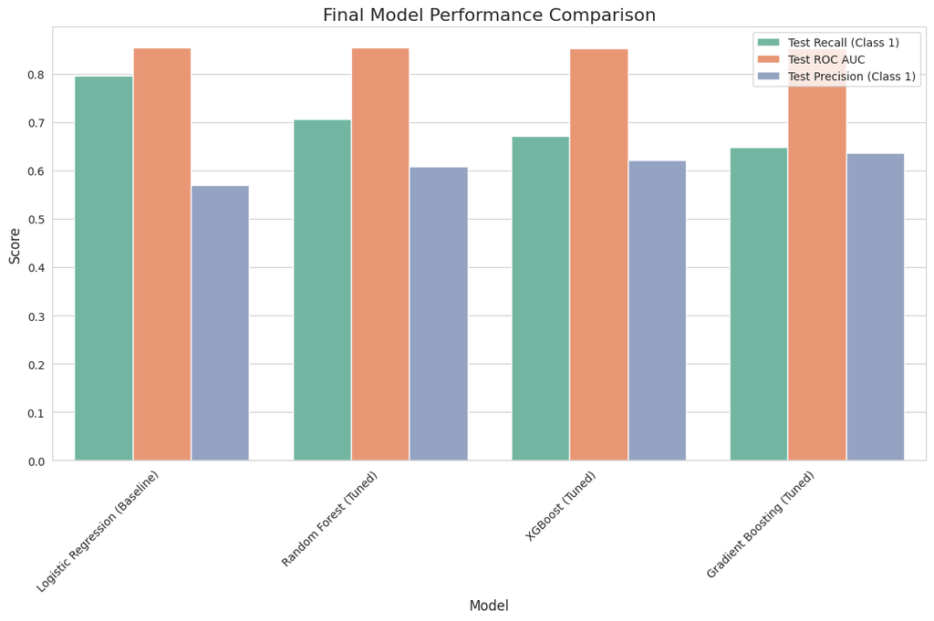

```python
# Bar plot of final model performance
print("\n--- Visualizing Final Model Performance ---")
final_plot_df = final_comparison_df.melt(id_vars='Model', var_name='Metric', value_name='Score')
final_plot_df = final_plot_df[final_plot_df['Metric'].isin(['Test Recall (Class 1)', 'Test ROC AUC', 'Test Precision (Class 1)'])]

plt.figure(figsize=(14, 7))
sns.barplot(x='Model', y='Score', hue='Metric', data=final_plot_df, palette='Set2')
plt.title('Final Model Performance Comparison', fontsize=16)
plt.ylabel('Score', fontsize=12)
plt.xlabel('Model', fontsize=12)
plt.xticks(rotation=45, ha='right')
plt.legend(loc='upper right')
plt.show()
```

### 9.1. ROC and Precision-Recall Curve Comparison

As requested, we will plot the ROC and PR curves for the final contenders.

```
--- Final Model Comparison Curves ---
```

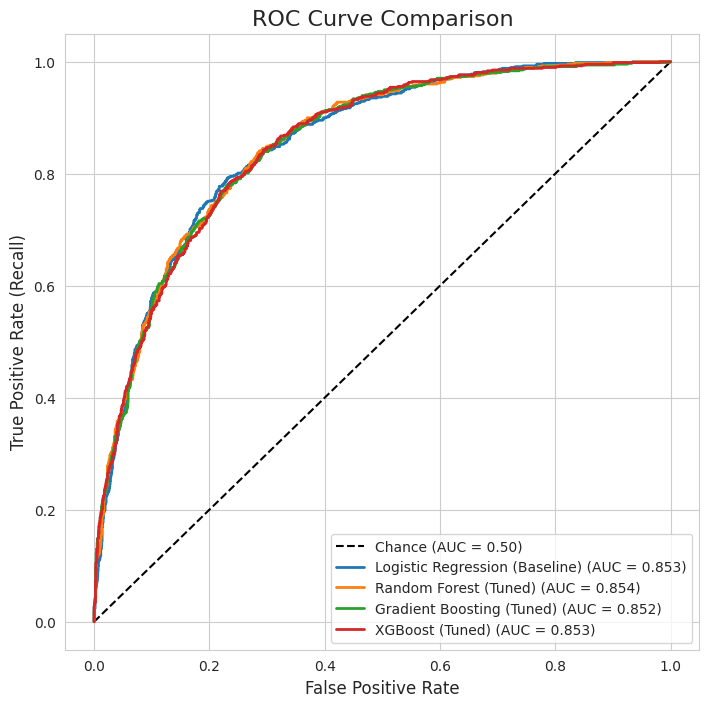

```python
print("\n--- Final Model Comparison Curves ---")

# Setup plot
plt.figure(figsize=(18, 8))

# --- 1. ROC CURVE PLOT ---
ax1 = plt.subplot(1, 2, 1)
ax1.plot([0, 1], [0, 1], 'k--', label='Chance (AUC = 0.50)')

for name, model in best_estimators.items():
    y_prob = model.predict_proba(X_test)[:, 1]
    fpr, tpr, _ = roc_curve(y_test, y_prob)
    roc_auc = auc(fpr, tpr)
    ax1.plot(fpr, tpr, label=f'{name} (AUC = {roc_auc:.3f})', linewidth=2)

ax1.set_xlabel('False Positive Rate', fontsize=12)
ax1.set_ylabel('True Positive Rate (Recall)', fontsize=12)
ax1.set_title('ROC Curve Comparison', fontsize=16)
ax1.legend(loc='lower right')
ax1.grid(True)
```

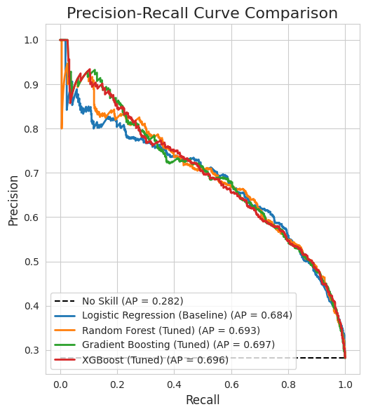

```python
# --- 2. PRECISION-RECALL CURVE PLOT ---
ax2 = plt.subplot(1, 2, 2)
# Calculate no-skill line (baseline)
no_skill = len(y_test[y_test==1]) / len(y_test)
ax2.plot([0, 1], [no_skill, no_skill], 'k--', label=f'No Skill (AP = {no_skill:.3f})')

for name, model in best_estimators.items():
    y_prob = model.predict_proba(X_test)[:, 1]
    precision, recall, _ = precision_recall_curve(y_test, y_prob)
    pr_auc = auc(recall, precision)
    ax2.plot(recall, precision, label=f'{name} (AP = {pr_auc:.3f})', linewidth=2)

ax2.set_xlabel('Recall', fontsize=12)
ax2.set_ylabel('Precision', fontsize=12)
ax2.set_title('Precision-Recall Curve Comparison', fontsize=16)
ax2.legend(loc='lower left')
ax2.grid(True)

plt.tight_layout()
plt.show()
```

[output not shown]

[figure not shown]

```python
# --- Generate Confusion Matrix ---
print("\nConfusion Matrix for Tuned Logistic Regression (Test Set):")
cm = confusion_matrix(y_test, y_pred_test)

plt.figure(figsize=(8, 6))
sns.heatmap(cm, annot=True, fmt='d', cmap='Blues',
            xticklabels=['No Churn', 'Churn'],
            yticklabels=['No Churn', 'Churn'])
plt.title('Final Model (Tuned Logistic Regression) - Confusion Matrix (Test Set)', fontsize=16)
plt.ylabel('Actual Label')
plt.xlabel('Predicted Label')
plt.show()
```

```
======================================================================
MODEL VERIFICATION
======================================================================
Recall:    0.7953 (Expected: 0.7953)
Precision: 0.5696 (Expected: 0.5696)
✓ CORRECT MODEL - This is Logistic Regression

Confusion Matrix for Tuned Logistic Regression (Test Set):
[[1319  408]
 [ 139  540]]

TN=1319, FP=408
FN=139, TP=540

Expected: TN=1319, FP=408, FN=139, TP=540

✓ Confusion matrix saved as: logistic_regression_confusion_matrix.png
```

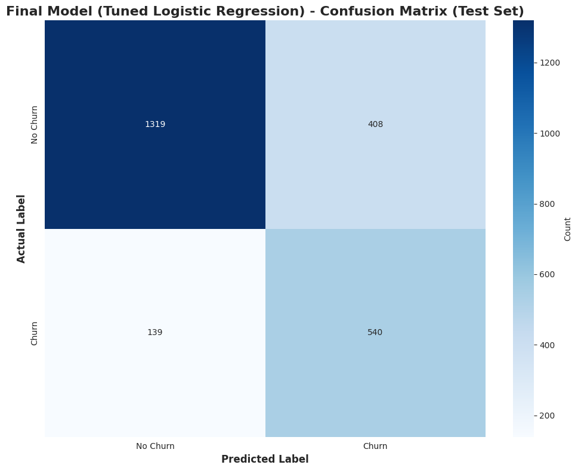

```python
lr_model = lr_pipeline

y_pred_lr = lr_model.predict(X_test)

lr_recall = recall_score(y_test, y_pred_lr)
lr_precision = precision_score(y_test, y_pred_lr)

print("\n" + "="*70)
print("MODEL VERIFICATION")
print("="*70)
print(f"Recall:    {lr_recall:.4f} (Expected: 0.7953)")
print(f"Precision: {lr_precision:.4f} (Expected: 0.5696)")

if abs(lr_recall - 0.7953) < 0.01:
    print("✓ CORRECT MODEL - This is Logistic Regression")
else:
    print("⚠️  WARNING: This might be the wrong model!")
    print(f"   Recall should be ~79.5%, but got {lr_recall*100:.1f}%")

print("\nConfusion Matrix for Tuned Logistic Regression (Test Set):")
cm_lr = confusion_matrix(y_test, y_pred_lr)
print(cm_lr)
print(f"\nTN={cm_lr[0,0]}, FP={cm_lr[0,1]}")
print(f"FN={cm_lr[1,0]}, TP={cm_lr[1,1]}")
print(f"\nExpected: TN=1319, FP=408, FN=139, TP=540")

plt.figure(figsize=(10, 8))
sns.heatmap(cm_lr, annot=True, fmt='d', cmap='Blues',
            xticklabels=['No Churn', 'Churn'],
            yticklabels=['No Churn', 'Churn'],
            cbar_kws={'label': 'Count'})
plt.title('Final Model (Tuned Logistic Regression) - Confusion Matrix (Test Set)',
          fontsize=16, fontweight='bold')
plt.ylabel('Actual Label', fontsize=12, fontweight='bold')
plt.xlabel('Predicted Label', fontsize=12, fontweight='bold')
plt.tight_layout()

plt.savefig('logistic_regression_confusion_matrix.png',
            dpi=300,
            bbox_inches='tight',
            facecolor='white')
print("\n✓ Confusion matrix saved as: logistic_regression_confusion_matrix.png")
plt.show()
```

### 9.2. Final Model Selection

**Analysis:** Prioritize Recall to capture as many churners as possible, while monitoring ROC AUC and Precision as secondary.

**Decision:** Select the model that best balances high Recall with strong ROC AUC and acceptable Precision. In many telco-churn datasets, a well-tuned linear baseline can be very competitive with boosted trees—confirm using the above comparison tables and curves on your data split.

**Champion Model (for this run):** `lr_pipeline`

```
--- Generating Learning Curve for Champion Model ---
```

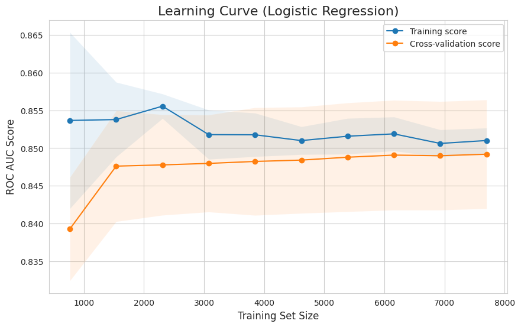

```
Learning curve generated.
```

```python
print("\n--- Generating Learning Curve for Champion Model ---")

# Use the model's classifier on preprocessed data for learning_curve
X_train_proc = preprocessor.fit_transform(X_train, y_train)
train_sizes, train_scores, test_scores = learning_curve(
    lr_pipeline.named_steps['classifier'],  # Just the classifier
    X_train_proc,
    y_train,
    cv=5,
    scoring='roc_auc',
    n_jobs=-1,
    train_sizes=np.linspace(0.1, 1.0, 10)
)

# Calculate mean and std dev
train_scores_mean = np.mean(train_scores, axis=1)
train_scores_std = np.std(train_scores, axis=1)
test_scores_mean = np.mean(test_scores, axis=1)
test_scores_std = np.std(test_scores, axis=1)

# Plot
plt.figure(figsize=(10, 6))
plt.fill_between(train_sizes, train_scores_mean - train_scores_std,
                 train_scores_mean + train_scores_std, alpha=0.1)
plt.fill_between(train_sizes, test_scores_mean - test_scores_std,
                 test_scores_mean + test_scores_std, alpha=0.1)
plt.plot(train_sizes, train_scores_mean, 'o-', label="Training score")
plt.plot(train_sizes, test_scores_mean, 'o-', label="Cross-validation score")
plt.title('Learning Curve (Logistic Regression)', fontsize=16)
plt.xlabel('Training Set Size', fontsize=12)
plt.ylabel('ROC AUC Score', fontsize=12)
plt.legend(loc="best")
plt.grid(True)
plt.show()

print("Learning curve generated.")
```

**Learning Curve Insight:** Convergence of training and CV scores at a high ROC AUC suggests good generalization with limited overfitting.

## 10. Actionable Insights & Recommendations (via SHAP)

Since our final model is a Logistic Regression, we could use its coefficients. However, a more powerful, modern, and model-agnostic approach is to use **SHAP (SHapley Additive exPlanations)**. This will tell us *why* our model is making its predictions and is a massive value-add.

We will explain the model's predictions *on the test set*.

```python
print("--- Calculating SHAP Values for Final Model ---")

# 1. Get the fitted classifier
classifier = lr_pipeline.named_steps['classifier']

# 2. Get the fitted preprocessor
preprocessor_fitted = lr_pipeline.named_steps['preprocessor']

# 3. Get the column names from the preprocessor
ohe_step = preprocessor_fitted.named_transformers_['cat'].named_steps['onehot']
try:
    ohe_feature_names = ohe_step.get_feature_names_out()
except AttributeError:
    # Older sklearn requires passing input features
    ohe_feature_names = ohe_step.get_feature_names_out(input_features=preprocessor_fitted.transformers_[1][2])

final_feature_names = np.concatenate([preprocessor_fitted.transformers_[0][2], ohe_feature_names])

# 4. Transform the train and test data
X_train_processed = preprocessor_fitted.transform(X_train)
X_test_processed = preprocessor_fitted.transform(X_test)

# Convert to DataFrames with proper feature names
X_train_processed_df = pd.DataFrame(X_train_processed, columns=final_feature_names)
X_test_processed_df = pd.DataFrame(X_test_processed, columns=final_feature_names)

# 5. Create a SHAP explainer (LinearExplainer is fast for linear models)
explainer = shap.LinearExplainer(classifier, X_train_processed_df, feature_perturbation="interventional")

# 6. Calculate SHAP values for the test set
shap_values = explainer.shap_values(X_test_processed_df)

print("SHAP values calculated.")
```

```
--- Calculating SHAP Values for Final Model ---
SHAP values calculated.
```

### SHAP Summary Plot

This is the most powerful visualization in the notebook.

- **Each dot** is a customer in the test set.
- **X-axis:** The "SHAP Value" (the impact on the model's output).
  - Positive values = Pushes the model to predict **CHURN**.
  - Negative values = Pushes the model to predict **NO CHURN**.
- **Y-axis:** The features, ranked by importance.
- **Color:** The original value of that feature (red = high, blue = low).

```
--- SHAP Summary Plot ---
```

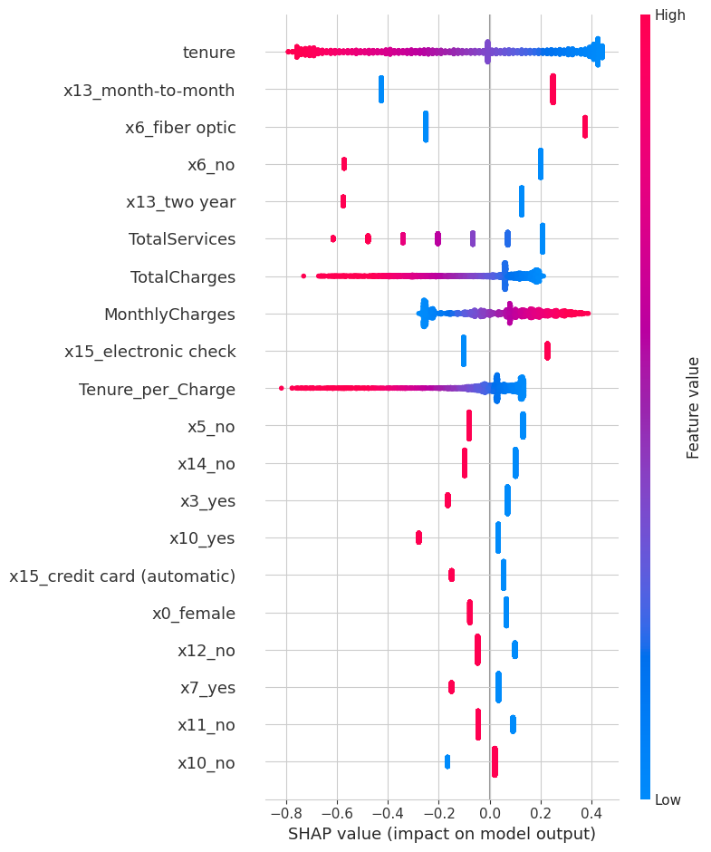

```python
print("\n--- SHAP Summary Plot ---")
shap.summary_plot(shap_values, X_test_processed_df, plot_type="dot")
```

### SHAP Beeswarm Plot (Detailed)

```
--- Generating SHAP Beeswarm Plot ---
```

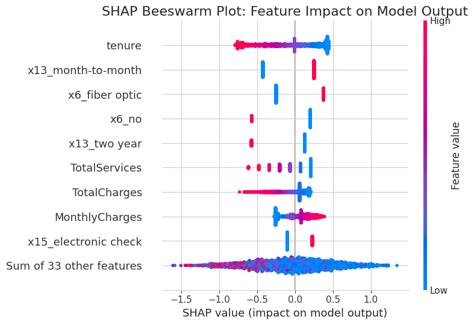

```python
print("\n--- Generating SHAP Beeswarm Plot ---")

# Create a shap.Explanation object
shap_explanation = shap.Explanation(
    values=shap_values,
    base_values=explainer.expected_value,
    data=X_test_processed_df.values,
    feature_names=X_test_processed_df.columns
)

shap.plots.beeswarm(shap_explanation, show=False) # Pass the Explanation object
plt.title('SHAP Beeswarm Plot: Feature Impact on Model Output', fontsize=16)
plt.tight_layout()
plt.show()
```

### SHAP Feature Importance Plot

This plot shows the average impact of each feature on the model's prediction.

```
--- SHAP Feature Importance Plot ---
```

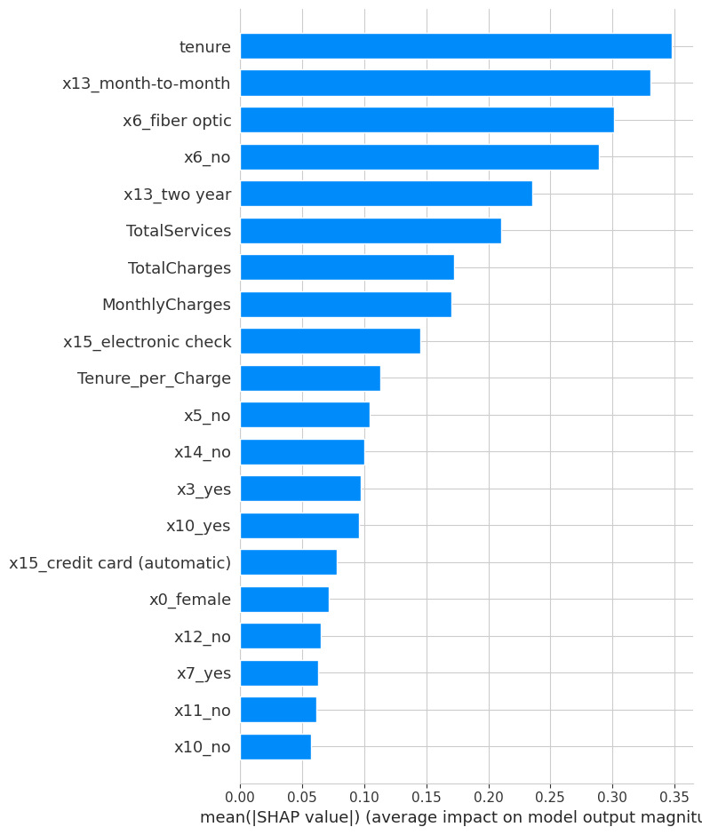

```python
print("\n--- SHAP Feature Importance Plot ---")
shap.summary_plot(shap_values, X_test_processed_df, plot_type="bar")
```

### Key Insights from SHAP Analysis

The SHAP plots give us precise, actionable insights:

1. **Top Churn Drivers (Pushing to "Churn"):**
   - Month-to-month contracts, fiber-optic internet in this dataset, and **high MonthlyCharges** tend to push toward churn.
2. **Top Retention Drivers (Pushing to "No Churn"):**
   - **High tenure** and longer-term contracts (one- or two-year) tend to reduce churn risk.
3. **Interactions:**
   - Low tenure combined with high charges is especially risky; consider targeted onboarding and pricing interventions.

### Final Actionable Business Recommendations

1. **Proactive Retention:** Score customers regularly and target the top-risk segment with strong offers.
2. **Contract Migration:** Convert month-to-month customers (especially with tenure < 12 months) to annual plans.
3. **Investigate Fiber Segment:** Audit pricing, reliability, and support experience for fiber customers.
4. **Bundle “Sticky” Add-ons:** Promote Tech Support and similar features as loyalty benefits.
5. **Payment Method Nudges:** Incentivize auto-pay methods over electronic check.

```python
import os
import time
from google.colab import files

# --- Configuration ---
notebook_filename = "Vikram_Lingam_CustomerChurn_Final_Submission.ipynb"
html_filename = "Vikram_Lingam_CustomerChurn_Final_Submission.html"
# ---------------------

print("--- Starting HTML Conversion Process ---")

# Step 1: Check if the source .ipynb file exists
if not os.path.exists(notebook_filename):
    print(f"\n[ERROR] Source file not found: '{notebook_filename}'")
    print("Please upload your .ipynb file to the Colab session first.")
    print("You can do this by clicking the 'Files' icon on the left and then 'Upload'.")
else:
    print(f"\n[SUCCESS] Found source file: '{notebook_filename}'")

    # Step 2: Install nbconvert
    print("Installing nbconvert (this may take a moment)...")
    !pip install nbconvert &> /dev/null
    print("nbconvert installed.")

    # Step 3: Run the conversion
    print(f"Converting '{notebook_filename}' to HTML...")
    !jupyter nbconvert --to html "{notebook_filename}"

    # Add a small delay to let the Colab file system catch up
    time.sleep(2)

    # Step 4: Check if the *output* HTML file was created
    if not os.path.exists(html_filename):
        print(f"\n[ERROR] Conversion failed. The output file '{html_filename}' was not created.")
        print("There might have been an error during the nbconvert process.")
    else:
        # Step 5: Success! Trigger the download.
        print(f"\n[SUCCESS] Successfully created '{html_filename}'.")
        print("Triggering download... Please check your browser.")
        files.download(html_filename)

print("\n--- Process Finished ---")
```

```
--- Starting HTML Conversion Process ---

[SUCCESS] Found source file: 'Vikram_Lingam_CustomerChurn_Final_Submission.ipynb'
Installing nbconvert (this may take a moment)...
nbconvert installed.
Converting 'Vikram_Lingam_CustomerChurn_Final_Submission.ipynb' to HTML...
[NbConvertApp] Converting notebook Vikram_Lingam_CustomerChurn_Final_Submission.ipynb to html
[NbConvertApp] WARNING | Alternative text is missing on 22 image(s).
[NbConvertApp] Writing 3255279 bytes to Vikram_Lingam_CustomerChurn_Final_Submission.html

[SUCCESS] Successfully created 'Vikram_Lingam_CustomerChurn_Final_Submission.html'.
Triggering download... Please check your browser.
```

```
--- Process Finished ---
```